# Exercícios Aula 8 - Mapas e Analises Espaciais

Beatriz Milz

08/05/2020

```r
library(nycflights13)
library(tidyverse)
library(knitr)
library(sf)
library(lwgeom)
```

## Exercício 1: Mapas de Pontos

**1.** Crie um objeto de simple features com os seguintes dados. Os valores de longitude e latitude são brutos em CRS 4326.

```r
dados_cidades <- tibble::tibble(
  cidade = c("Paris", "London", "Istanbul", "Madrid", "Berlin"),
  pais = c("France", "United Kingdom", "Turkey", "Spain", "Germany"),
  populacao = c(12006868, 11984435, 11400000, 6633278, 5142247),
  long = c(2.352552,-0.128285, 28.976636,-3.708597, 13.402067),
  lat = c(48.85771, 51.50724, 41.00799, 40.41167, 52.52013)
)

dados_cidades_sf <-
  dados_cidades %>% st_as_sf(coords = c("long", "lat"), crs = 4326)

dados_cidades
```

| cidade | pais | populacao | long | lat |
| --- | --- | --- | --- | --- |
| Paris | France | 12006868 | 2.352552 | 48.85771 |
| London | United Kingdom | 11984435 | -0.128285 | 51.50724 |
| Istanbul | Turkey | 11400000 | 28.976636 | 41.00799 |
| Madrid | Spain | 6633278 | -3.708597 | 40.41167 |
| Berlin | Germany | 5142247 | 13.402067 | 52.52013 |

**2.** Visualize um mapa simples dos seus dados com ggplot(), com um cor diferente para cada ponto baseado na variável População.

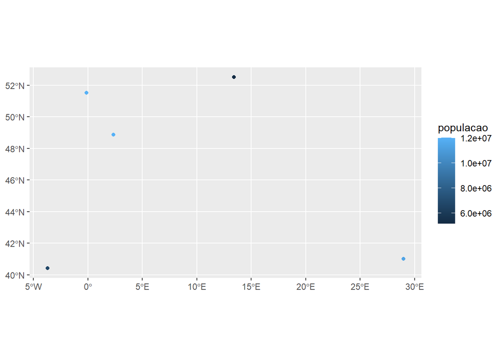

```r
dados_cidades_sf %>% ggplot() +
  geom_sf(aes(color = populacao))
```

**3.** Quando criando o seu objeto sf, pode usar o argumento remove=FALSE para preservar as colunas de longitude e latitude explicitamente. Use essas duas colunas para adicionar mais uma camada de geometria que imprime os rótulos dos nomes das cidades ao seu mapa.

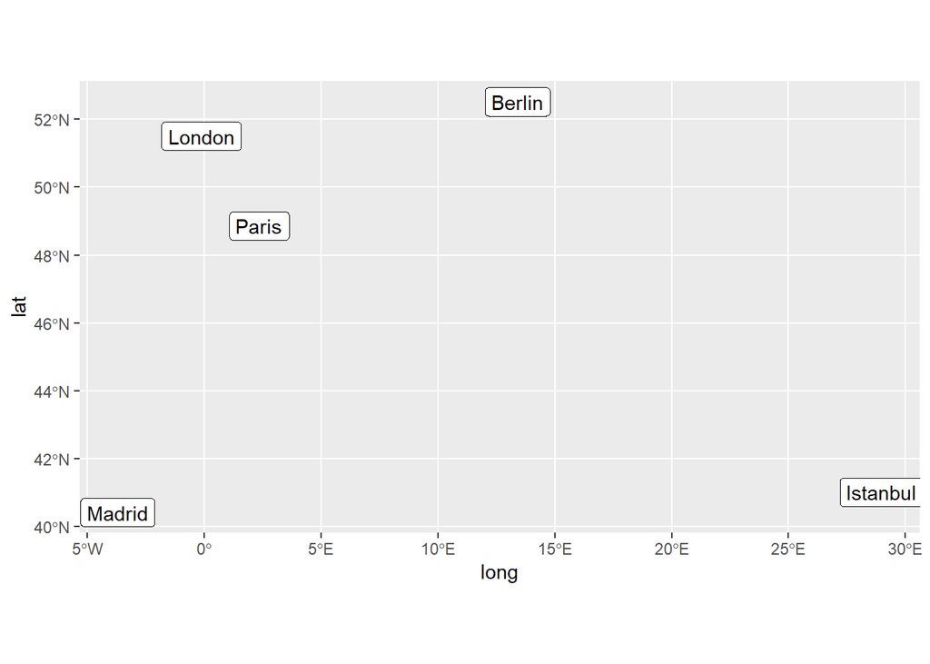

```r
dados_cidades %>% st_as_sf(coords = c("long", "lat"),
                           crs = 4326,
                           remove = FALSE) %>%
  ggplot() +
  geom_sf() +
  geom_sf_label(aes(long, lat, label = cidade))
```

**4.** Tirar os rótulos dos nomes das cidades e transforme os seus dados par a projeção com CRS 23035, e apresente um novo mapa.

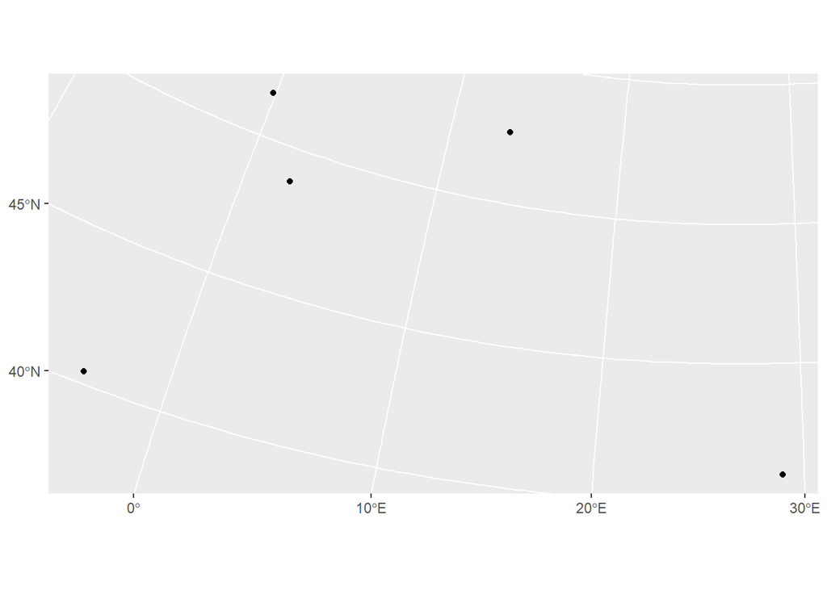

```r
dados_cidades_sf %>% st_transform(crs = 23035) %>%
  ggplot() +
  geom_sf()
```

**5.** Calcule o matriz da distância euclidiana entre os pontos.

```r
dados_cidades_sf_23025 <- dados_cidades_sf %>% st_transform(crs = 23035)


dados_cidades_sf_23025 %>% st_distance()
```

```
## Units: [m]
##           [,1]      [,2]    [,3]    [,4]      [,5]
## [1,]       0.0  357954.7 2287041 1117897  899765.3
## [2,]  357954.7       0.0 2537735 1342891  957098.0
## [3,] 2287041.3 2537735.2       0 2817123 1744466.2
## [4,] 1117896.6 1342891.0 2817123       0 1948858.8
## [5,]  899765.3  957098.0 1744466 1948859       0.0
```

## Exercício 2: Mapas mais Completos

1. Abre o shapefile dos países da Europa no link aqui. Mostre um mapa simples usanda a projeção 23035

```r
europa <- sf::st_read("dados/Europe/Europe.shp")
```

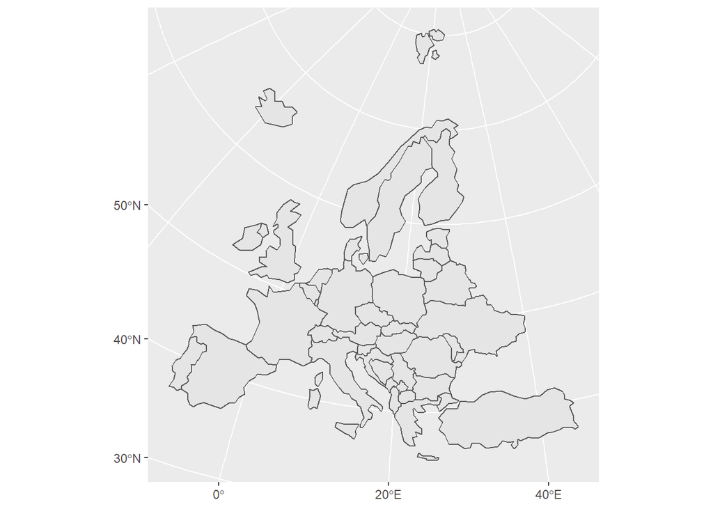

```r
europa %>% st_transform(crs = 23035) %>%
  ggplot() +
  geom_sf()
```

2. Adicione os dados das cidades do Exercício 1 ao seu mapa de Europa de Questão 1 e formate o mapa com um tema, título etc. apropriado.

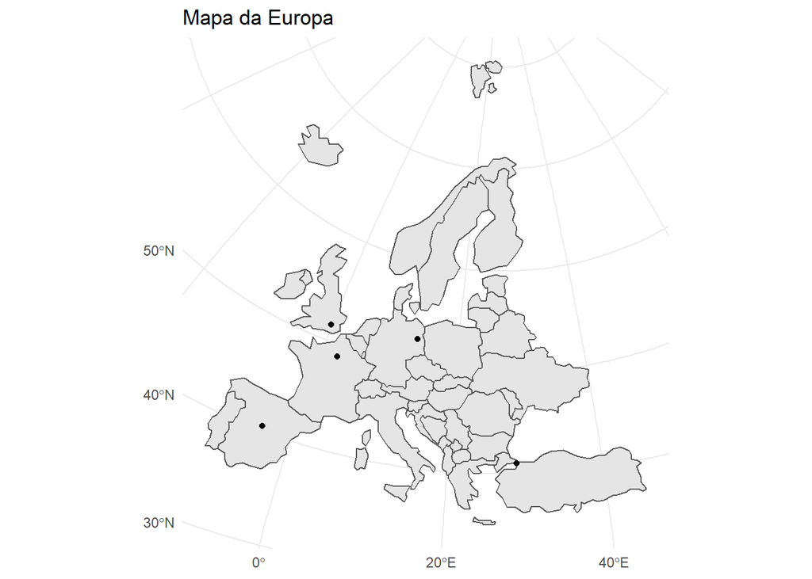

```r
europa %>% st_transform(crs = 23035) %>%
  ggplot() +
  geom_sf() +
  geom_sf(data = dados_cidades_sf_23025) +
  labs(title = "Mapa da Europa") +
  theme_minimal()
```

3. Desenvolvendo o mesmo mapa, para cada país da Europa, visualize a população nacional (variável POP_EST) no mapa, com uma escala e legenda apropriada.

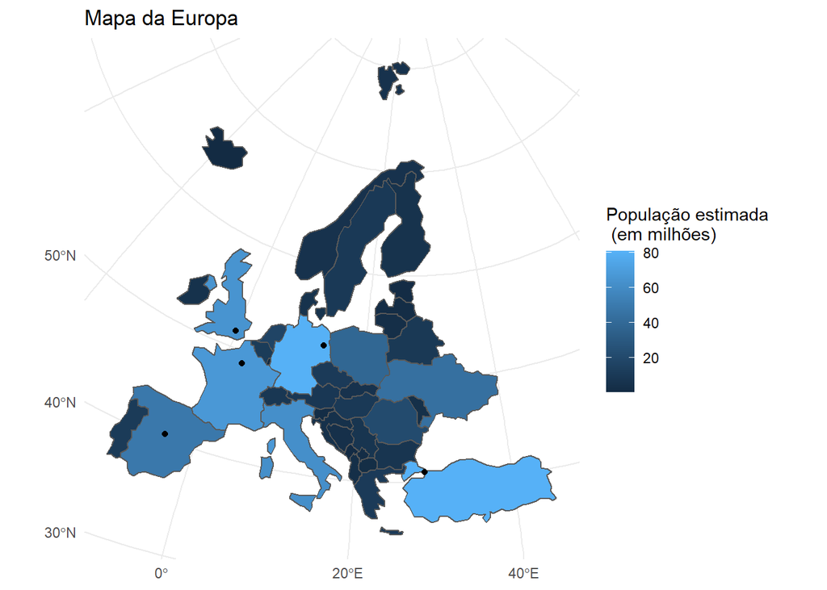

```r
europa %>% st_transform(crs = 23035) %>%
  mutate(pop_estimada = POP_EST/1000000) %>%
  ggplot() +
  geom_sf(aes(fill = pop_estimada)) +
  geom_sf(data = dados_cidades_sf_23025) +
  # geom_sf_label(aes(label = POP_EST))
  labs(title = "Mapa da Europa", fill = "População estimada \n (em milhões)") +
  theme_minimal()
```

4. Queremos adicionar a próxima cidade na lista, Milão, mas não sabemos o longitude e latitude da cidade. Georeferencie o endereço de “Piazza del Duomo, 20122 Milano, Italy”, e (em vez de juntar com o banco de dados de cidades), adicione os resultados como mais uma camada do seu mapa de Questão 43 com a mesma formatação da camada do resto das cidades.

```r
dados_italia <- tibble::tibble(
  cidade = c("Milão"),
  pais = c("Italia"),
  endereco = c("“Piazza del Duomo, 20122 Milano, Italy”")
)

# tmaptools::geocode_OSM(dados_italia$endereco, projection = 4326, as.sf = T)

# Não está dando certo a função geocode_OSM
```

## Exercício 3: Joins para Mapas

1. Juntar os dois bancos de Cidades e Países Europeus usando o nome do país. O resultado deve ser os pontos das cidades. (Uma das nossas tabelas tem que ser um tibble simples (não sf), então use a função st_drop_geometry() para voltar a uma tabela simples). Mostre num mapa a população dos países de cada cidade.

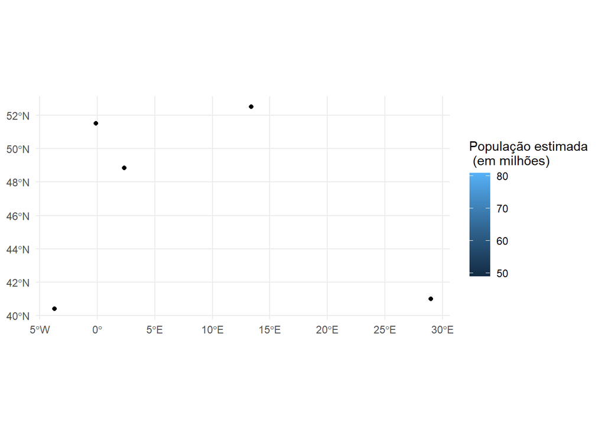

```r
europa_s_geo <- europa %>% st_drop_geometry()

left_join(dados_cidades_sf, europa_s_geo, by = c("pais" = "NAME")) %>%
  mutate(pop_estimada = POP_EST / 1000000) %>%
  ggplot() +
  geom_sf(aes(fill = pop_estimada)) +
  labs(fill = "População estimada \n (em milhões)") +
  theme_minimal()
```

2. Juntar os dois bancos de cidades e países Europeus usando um join espacial. O resultado deve ser os pontos das cidades. Reproduza o mapa de Questão 1.

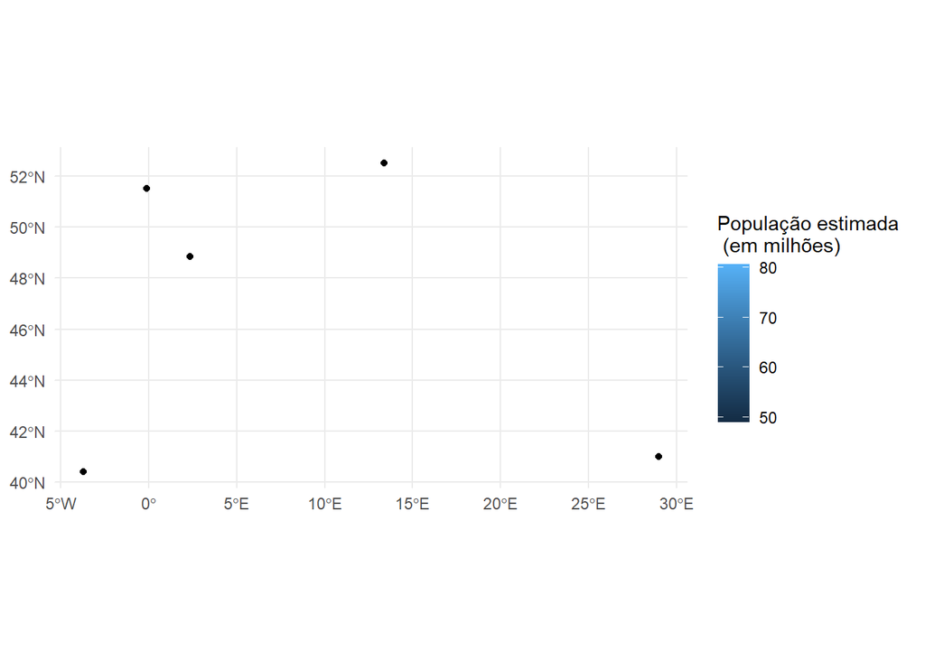

```r
st_join(dados_cidades_sf, europa) %>%
  mutate(pop_estimada = POP_EST / 1000000) %>%
  ggplot() +
  geom_sf(aes(fill = pop_estimada)) +
  labs(fill = "População estimada \n (em milhões)") +
  theme_minimal()
```

3. Juntar os dois bancos de cidades e países Europeus usando o nome do país. O resultado deve ser os polígonos dos países. Mostre num mapa a população das cidades metropolitanas.

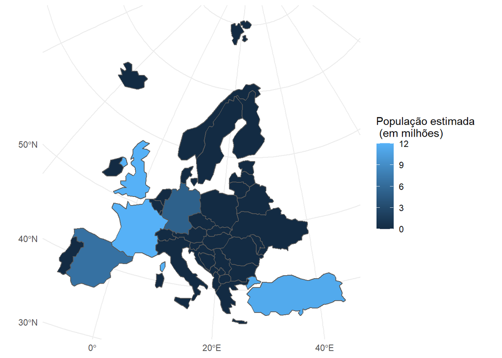

```r
europa %>%    st_transform(23035) %>% left_join(dados_cidades,  by = c("SOVEREIGNT"= "pais")) %>%
  group_by(SOVEREIGNT) %>%
  summarise(pop_total = sum(populacao, na.rm = TRUE)) %>%
   mutate(pop_total_milhoes= pop_total / 1000000) %>%
  ggplot() +
  geom_sf(aes(fill = pop_total_milhoes))+
  labs(fill = "População estimada \n (em milhões)") +
  theme_minimal()
```

4. Juntar os dois bancos de cidades e países Europeus usando um join espacial. Reproduza o mapa de Questão 3.

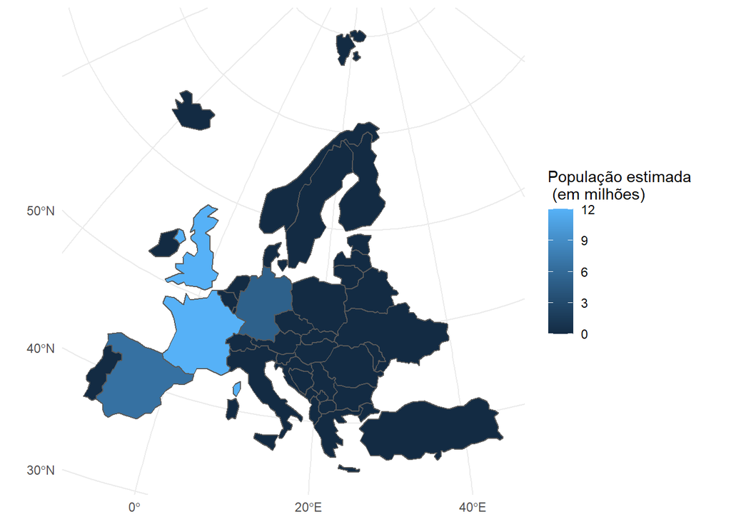

```r
europa %>%  st_transform(23035) %>%
  st_join(dados_cidades_sf %>%  st_transform(23035),  by = c("SOVEREIGNT"= "pais")) %>%
  group_by(SOVEREIGNT) %>%
  summarise(pop_total = sum(populacao, na.rm = TRUE)) %>%
   mutate(pop_total_milhoes= pop_total / 1000000) %>%
  ggplot() +
  geom_sf(aes(fill = pop_total_milhoes))+
  labs(fill = "População estimada \n (em milhões)") +
  theme_minimal()
```